# Chapter Three Homework

Cameron Smith

Sep 11, 2018

1. In the Flight Delays Case Study in Section 1.1,
   1. The data contain flight delays for two airlines, American Airlines and United Airlines. Conduct a two-sided permutation test to see if the mean delay times between the two carriers are statistically significant.
   2. The flight delays occured in May and June of 2009. Conduct a two-sided permutation test to see if the difference in mean delay times between the 2 months is statistically significant.

> $H_0:\mu_{AA} - \mu_{UA} = 0 versus H_A:\mu_{AA} - \mu_{UA} \neq 0$ $H_0:\mu_{JUNE} - \mu_{MAY} = 0 versus H_A:\mu_{JUNE} - \mu_{MAY} \neq 0$

```r
FD <- FlightDelays
# glimpse(FD)
# a. Your code here
FD %>%
  group_by(Carrier) %>%
  summarize(m = n(), mean = mean(Delay), SD = sd(Delay))
```

```
# A tibble: 2 x 4
  Carrier     m  mean    SD
  <fct>   <int> <dbl> <dbl>
1 AA       2906  10.1  40.1
2 UA       1123  16.0  45.1
```

```r
Delay <- FD$Delay
sims <- 10^4 - 1
ans <- numeric(sims)
for (i in 1:sims) {
  index <- sample(4029, 2906, FALSE)
  ans[i] <- mean(Delay[index]) - mean(Delay[-index])
}

OBS <- tapply(Delay, FD$Carrier, mean)
OBS_DIFF <- OBS[1] - OBS[2]

pval <- (sum(ans < OBS_DIFF && ans > -OBS_DIFF) + 1)/(sims + 1)
pval
```

```
[1] 1e-04
```

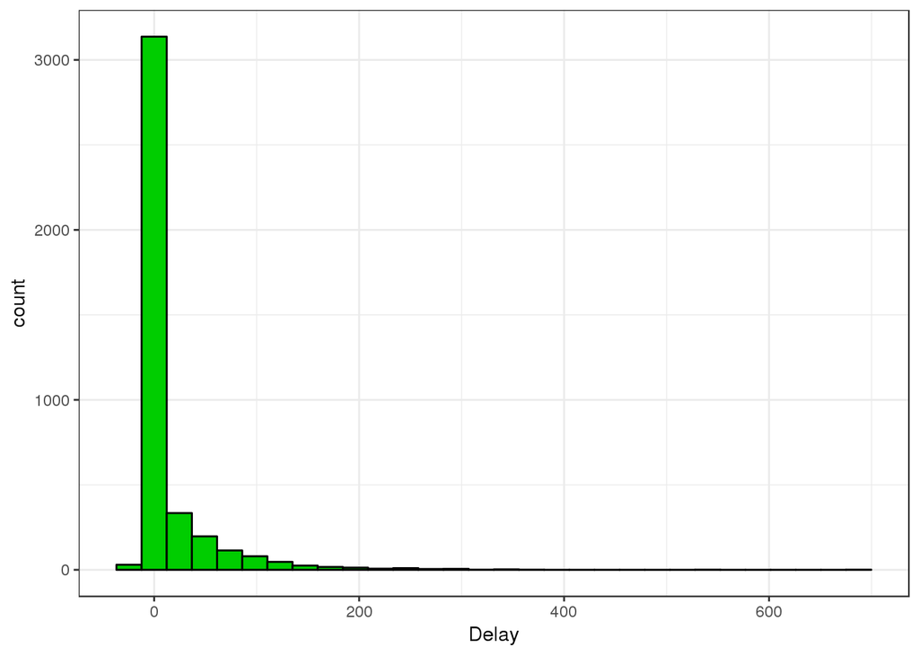

```r
#shape of delays
ggplot(data = FD, aes(x = Delay)) +
  geom_histogram(color = "black", fill = "555555") +
  theme_bw()
```

```r
#median of delays
median(Delay)
```

```
[1] -3
```

```r
#inner quartile range of delay
IQR(Delay)
```

```
[1] 11
```

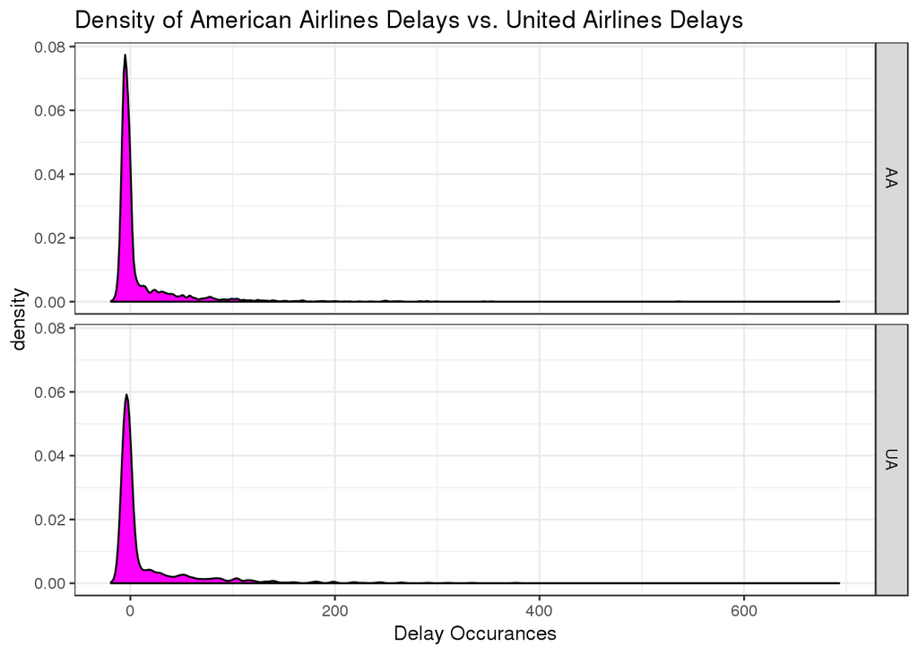

```r
#shape of American Airlines vs. United Airlines
ggplot(data = FD, aes(x = Delay)) +
  geom_density(color = "black", fill = "222222") +
  theme_bw() +
  facet_grid(FD$Carrier~.) +
  labs(title = "Density of American Airlines Delays vs. United Airlines Delays", x = "Delay Occurances")
```

```r
summary <- FD %>%
  group_by(Carrier) %>%
  summarize(median = median(Delay),IQR = IQR(Delay), mean = mean(Delay), SD = sd(Delay))

summary
```

```
# A tibble: 2 x 5
  Carrier median   IQR  mean    SD
  <fct>    <dbl> <dbl> <dbl> <dbl>
1 AA          -3  10    10.1  40.1
2 UA          -1  17.5  16.0  45.1
```

```r
OD <- summary$mean[1] - summary$mean[2]
OD
```

```
[1] -5.885696
```

```r
##ggplot(data = DF, aes(x=pmdiffs)) +
  ##geom_histogram(binwidth = 0.25, color = "black", fill = "purple") +
  ##theme_bw()
```

> SOLUTION:

```r
FD %>%
  group_by(Month) %>%
  summarize(m = n(), mean = mean(Delay), SD = sd(Delay))
```

```
# A tibble: 2 x 4
  Month     m  mean    SD
  <fct> <int> <dbl> <dbl>
1 May    1999  8.88  37.1
2 June   2030 14.5   45.5
```

```r
Delay <- FD$Delay
sims <- 10^4 - 1
ans <- numeric(sims)
for (i in 1:sims) {
  index <- sample(4029, 2030, FALSE)
  ans[i] <- mean(Delay[index]) - mean(Delay[-index])
}

OBS <- tapply(Delay, FD$Month, mean)

OBS_DIFF <- OBS[1] - OBS[2]

pval <- (sum(ans <= OBS_DIFF) + 1)/(sims + 1)
pval
```

```
[1] 1e-04
```

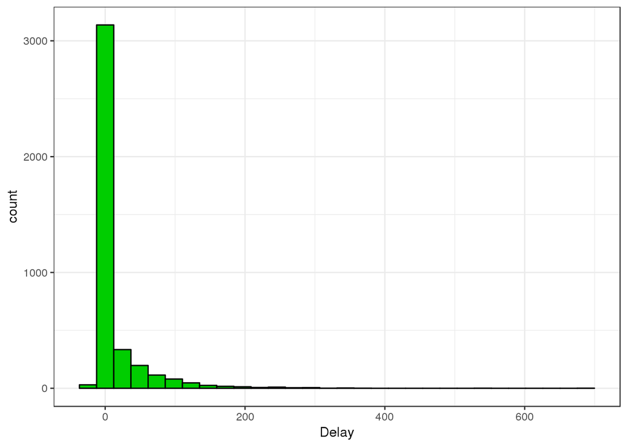

```r
#shape of delays
ggplot(data = FD, aes(x = Delay)) +
  geom_histogram(color = "black", fill = "555555") +
  theme_bw()
```

```r
#median of delays
median(Delay)
```

```
[1] -3
```

```r
#inner quartile range of delay
IQR(Delay)
```

```
[1] 11
```